# a very basic intro to version control and git

Sitaram Chamarty (sitaramc@gmail.com)

# 1 preface

# why

[figure not shown]

# what is a VCS

# why use a VCS

- reversibility or rollback, aka C-Y-A!
  - linear (on the time axis), simple to implement
- concurrency
  - non-linear, all the complexity is here
- annotation

# 2 some simple operations

# creating a repository

- how hard is it?

# an empty directory

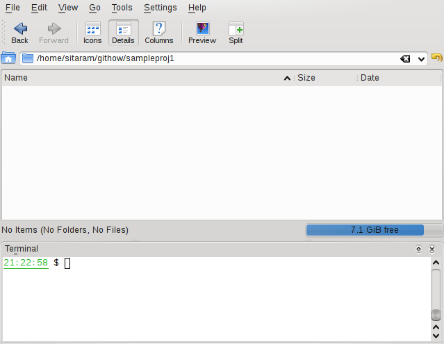

# add some files

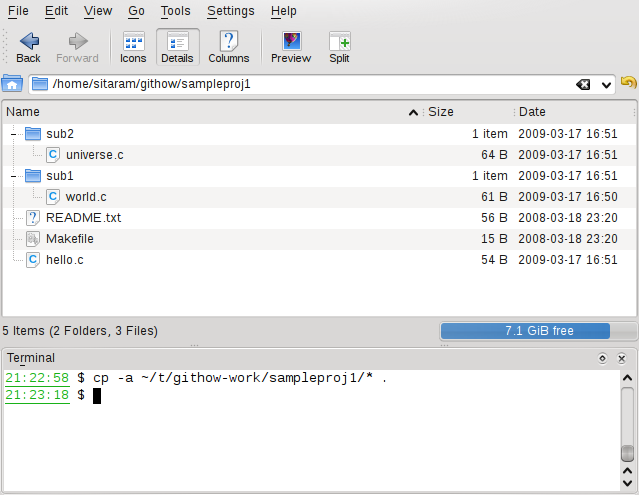

# ‘git init’ – done!

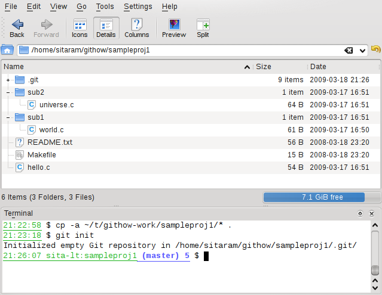

# how about on windows?

[figure not shown]

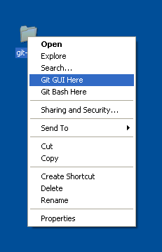

[figure not shown]

[figure not shown]

# done!

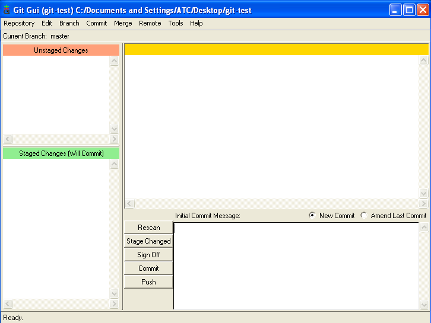

# double check…

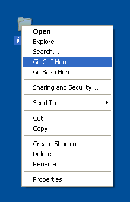

# yup – works fine!

[figure not shown]

# CLI on windows?

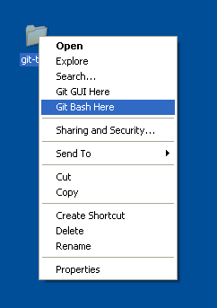

# a bash shell

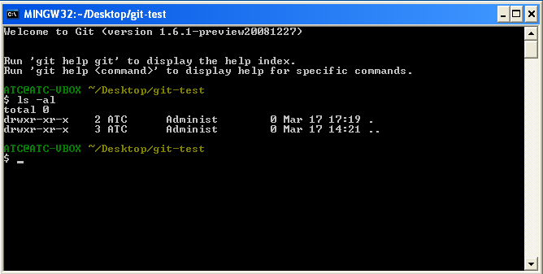

# ‘git init’ – done!

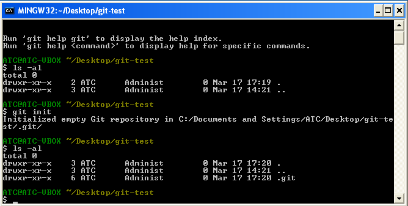

# 3 basic definitions

# what is a ‘work tree’

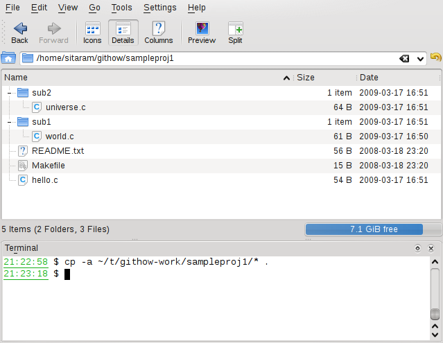

# what is a ‘repo’

- A repository is just
  - a work tree, plus
  - a special ‘.git’ directory at the top level of the work tree.
- NEVER FIDDLE WITH THIS DIRECTORY UNLESS YOU KNOW WHAT YOU ARE DOING!
- YOU HAVE BEEN WARNED!

# repository

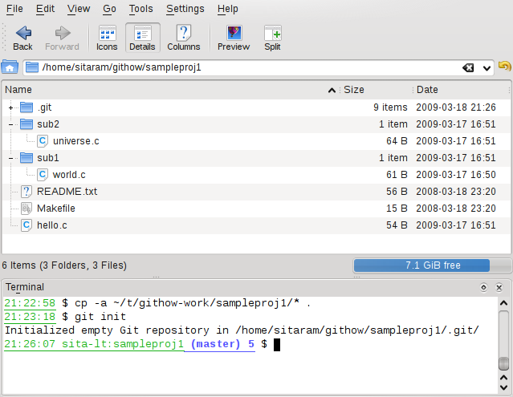

# (what’s inside ‘.git’?)

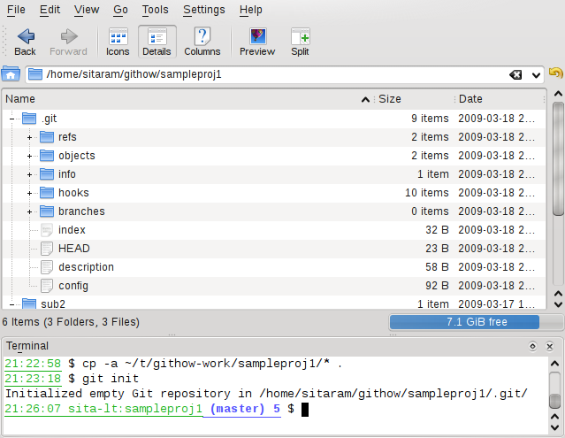

# 4 non-linear snapshots…

# ‘non-linear’

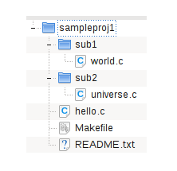

- a repository keeps snapshots of the work tree…
- …at different points in time

# snap

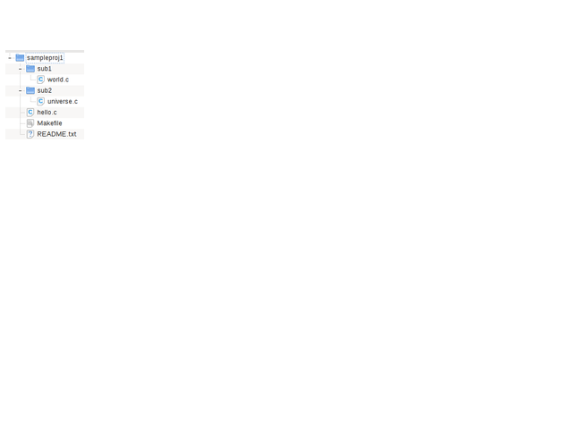

# snapshots

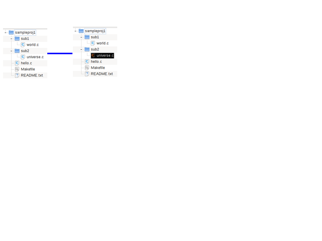

# snapshots of the work tree

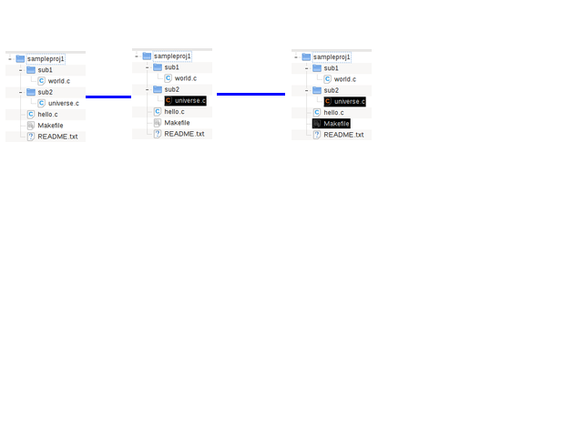

# at different

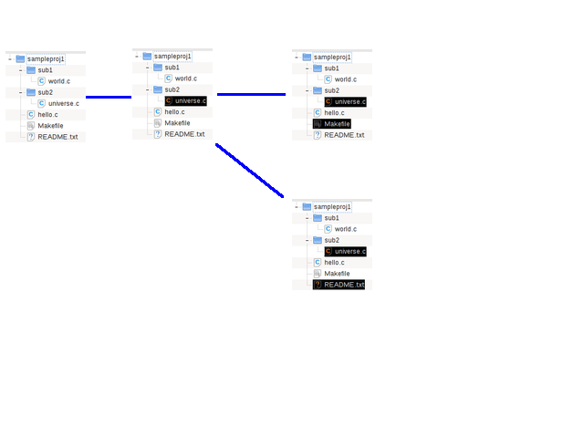

# at different points

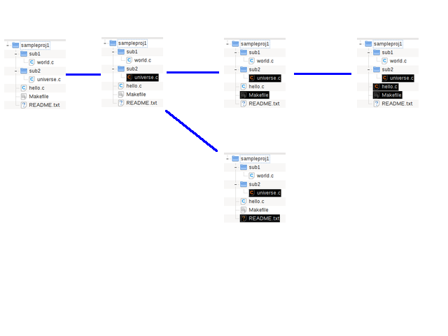

# at different points in time

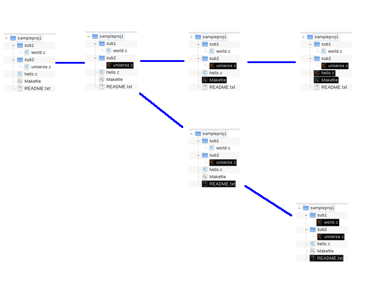

# 5 definitions revisited

# what is a commit

remember those snapshots? Yup – they’re all commits!

Here, to refresh your memory:

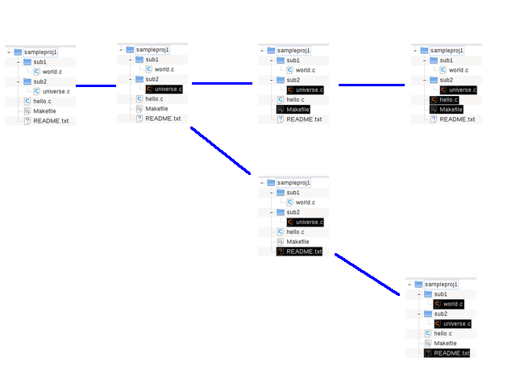

# what is a repo again?

- a work tree + .git? sure, but also…
- a bunch of commits laid out as a ‘graph’
  - a “directed acyclic graph”, if you’re interested

# DAG

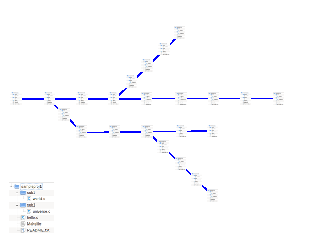

# 6 branches and tags

# what is a branch

- since a graph is sort of the same as a tree (for our purposes)
  - it has branches
  - and those branches have names

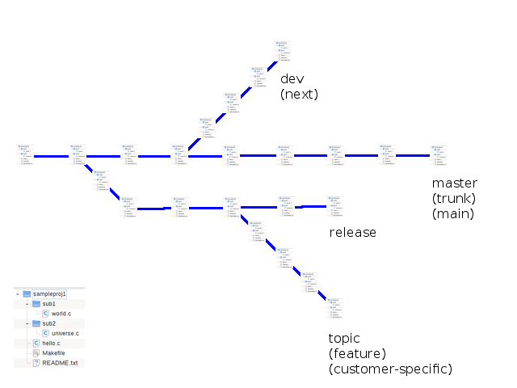

# what is a tag

- when you checkout a branch and then commit, the branch is now pointing at the new ‘snapshot’. This means…
- …the branch ‘tip’ keeps moving with every commit
- But sometimes you want to mark a point in your development
  - with some sort of a permanent label
  - that stays right there, even if you add commits on top

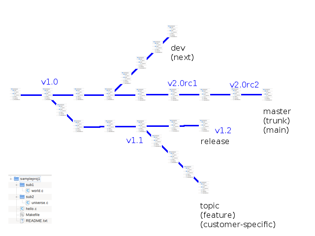

# 7 DVCS and git concepts

# general VCS concepts

- “project”: minimum set of source code (and related files) needed to **build** the software
- in a CVCS (Centralised VCS)
  - each project will have exactly one “repository”
  - on some central server
  - and each developer will checkout the project
    - from the server to his workstation

# a DVCS is different

- each project will have one “central” repository
  - (maybe; see next slide)
- but each repository can have many “clones”
- so each developer has a clone on his workstation
  - a complete copy of the repository
  - plus his own work/changes

# central repo in a DVCS?

- the developers can push and pull from each other directly
  - because they’re also repositories just like the “central” one
- so do we still need a “central” repo?
  - not really; that’s only an administrative decision now
  - not a technical requirement
  - but it makes managing projects easier
  - so yes, we still have central repos for most projects

# what is a ‘remote’

# git concepts

- repo
  - self-contained; remove “.git” at the top and it’s all gone
- branch
  - an active line of development
  - a repo can track any number of branches
- master
  - name of default branch in a new git project

# branches

- easy and inexpensive
- can have separate branches for separate features
- many being worked on “simultaneously”!
- you can switch rapidly between branches
- boosts individual productivity as well as team productivity
- almost all existing VCSs suck at this

#### branch also boost individual productivity

- concurrency
- makes context switching trivial

# git concepts (cont’d)

- working tree
  - is associated with only one branch at any time
- head
  - the tip of a branch
- HEAD
  - the tip of the branch associated with your working tree; this is where commits go

# git concepts (cont’d)

- index: holding area for changes approved for commit
  - git tracks content, not files
  - lets you select some files to commit while postponing others
  - lets you keep uncommited changes hanging around

# some more git concepts

- commit ancestry
- commit ancestry as a DAG
  - the essence of git is to build and traverse this DAG
  - https://sitaramc.github.com/gcs.html
- universal public identifier (a SHA-1 hash)
  - every file, directory, and commit has a unique hash
  - check the integrity of an entire repo by comparing just one 160-bit value (40 hex digits)

# 8 workflow

# git developer workflow

- far better than anything I can try:
  - https://nathanj.github.com/gitguide
- so I’ll just describe things at a high level

# one-time setup

- per developer
  - set up your name and email address
- per developer per project
  - ‘git init’ (the first guy)
  - ‘git clone …’ (the others)

# err… clone? from where?

- git servers and protocols (note: git does NO access control!)
  - ssh (RW, access control by ssh)
  - file protocol (RW, access control by OS)
  - git protocol (RO, access control by OS/firewall etc)
    - needs git daemon to be started first
  - old style http (RO, access control by Apache)
    - RW possible but painful; requires WebDAV
  - new style http (RW, access control by apache)
    - requires git 1.6.6 or better on both server and client

# many users/repos?

- just install ‘gitolite’ and be done!
- gitolite can provide fine-grained access control
- works over sshd or apache
  - sshd (or httpd) authenticates the user
  - passes the username to gitolite
  - gitolite uses the authenticated username, looks at the config file, and makes the authorisation decision

# normal workflow activities

- checkout a branch
- edit files
- review your changes (‘git diff’, or ‘git gui’)
- review other people’s changes or your older commits (‘gitk’ – a very powerful GUI tool)
- stage and commit them

# normal workflow activities

- push your commits to the server
- push failed? maybe your teammates committed something recently?
  - pull from the server first
  - their changes get merged into your local repo
  - then you push…

# clean and dirty work tree

- clean: all changes committed to local repo
- dirty: some files changed, and changes not yet committed
- PULL IS BEST DONE ON A CLEAN TREE!

### clean tree - CLI

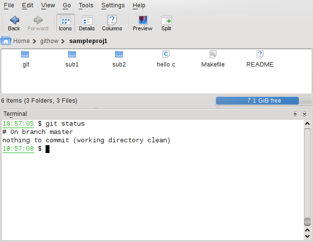

### clean tree - GUI

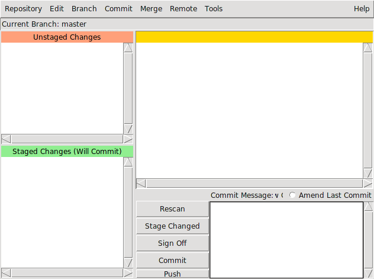

### dirty tree - CLI

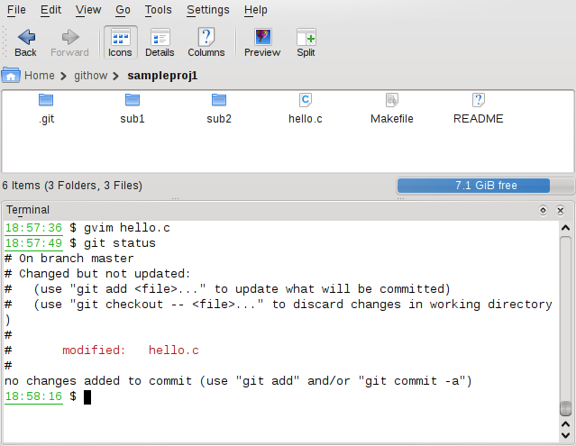

### dirty tree - GUI

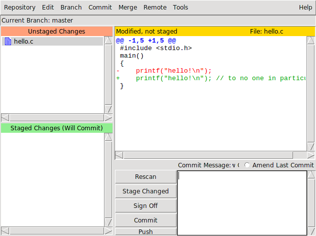

### staging from the GUI

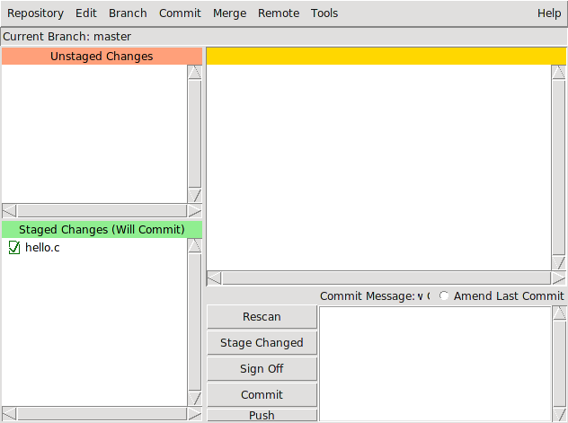

### staged files - CLI

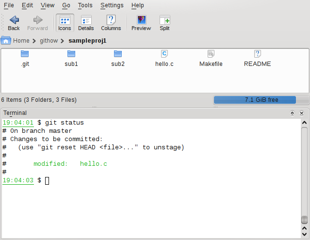

### committing from the GUI

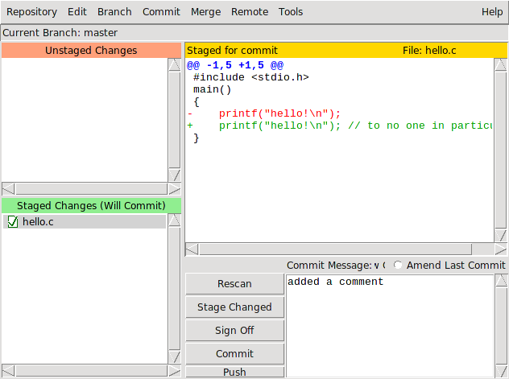

### clean again!

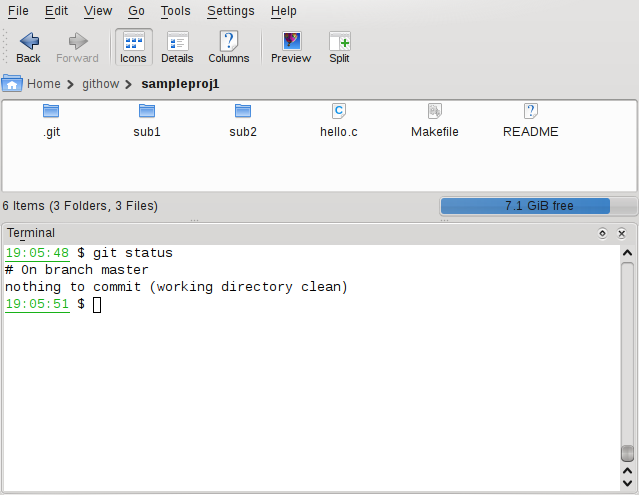

# 9 (other topics)

# conflicts

- what is a conflict
- how do you resolve it?

# advanced workflow activities

- cherry-pick – pick up specific changes from another branch or repo and make those changes happen in your repo
- rebase – move commits around; sort of like
  - cut off a branch where it connects to the trunk of a tree…
  - …and graft it somewhere else
- bisect